# Consistency of Random Forest/Randomer Forest

## 1.2 Sample Draw (n=1000)

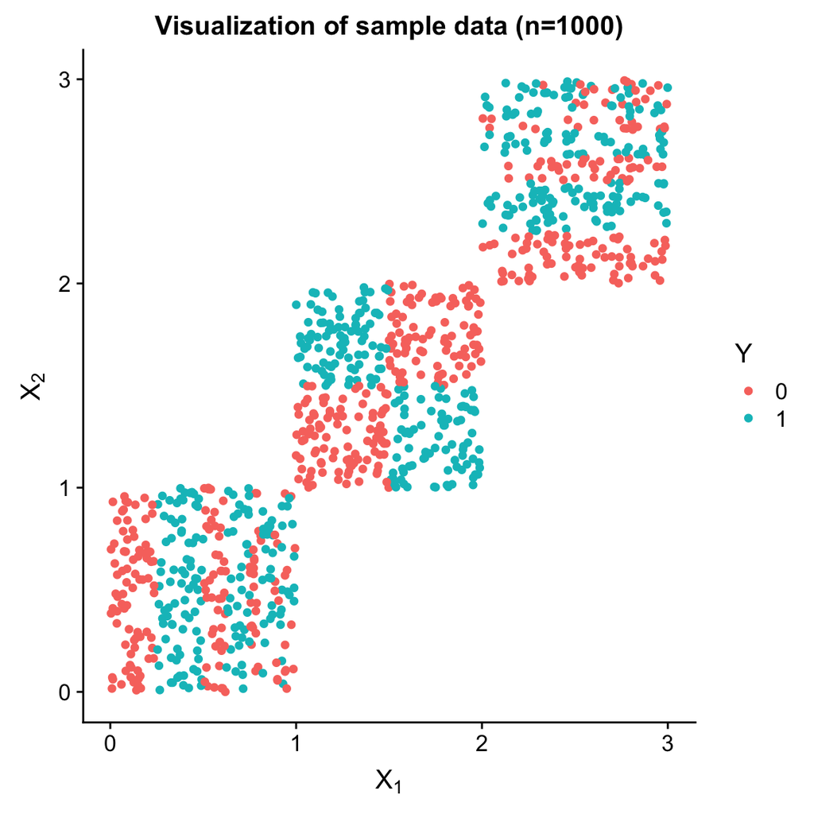

```r
createData <- function(n, seed = NULL) {
  if (!is.null(seed)) {
    set.seed(seed)
  }

  # Generate distribution of Y
  sequence <- getY(50)
  df <- data.frame(min = sequence[1:length(sequence) - 1],
                   max = sequence[2:length(sequence)],
                   label = rep(c(0, 1), (length(sequence) - 1) / 2))

  df2 <- data.frame(min = sequence[1:length(sequence) - 1] + 2,
                    max = sequence[2:length(sequence)] + 2,
                    label = rep(c(0, 1), (length(sequence) - 1) / 2))

  df <- rbind(df, df2)

  squares <- sample(c(1, 2, 3), n, replace = TRUE)
  Y <- integer(n)
  X <- matrix(0, nrow = n, ncol = 2)

  for (i in 1:n) {
    square <- squares[i]
    point <- runif(2, min = square - 1, max = square)

    X[i, ] <- point
    if (square == 2) {
      if ((point[1] <= 1.5 & point[2] > 1.5) | (point[1] > 1.5 & point[2] <= 1.5)) {
        Y[i] <- 1
      }
    } else if (square == 1) {
      Y[i] <- df$label[(point[1] >= df$min) & (point[1] < df$max)]
    } else if (square == 3) {
      Y[i] <- df$label[(point[2] >= df$min) & (point[2] < df$max)]
    }
  }
  return(list(X = X, Y = factor(Y)))
}

visualizeData <- function(n) {
  out <- createData(n, seed = NULL)
  X <- out$X
  Y <- out$Y

  qplot(X[, 1], X[, 2], color = Y) + labs(x = expression(X[1]), y = expression(X[2]),  title = paste0("Visualization of sample data (n=", n, ")"))
}

visualizeData(1000)
```

# 2 Running Experiment

Error rates are estimated by taking a random sample of size $n$, training the classifiers (RF/RerF), and computing the fraction misclassified in a test set of 10,000 samples. This is repeated ten times for each value of $n$. The reported error rate is the mean over the ten repeated experiments.

```r
# Data wrangling for plotting
errors.rerf <- matrix(NA, ncol = 4, nrow = 10)
errors.rf <- matrix(NA, ncol = 4, nrow = 10)

for (i in 1:10) {
  tmp <- errors[[i]]
  errors.rerf[i, ] <- tmp$errors.rerf
  errors.rf[i, ] <- tmp$errors.rf
}

errors.rerf.se <- apply(errors.rerf, 2, sd)
errors.rf.se <- apply(errors.rf, 2, sd)

errors.rerf.se <- errors.rerf.se / sqrt(length(errors.rerf.se))
errors.rf.se <- errors.rf.se / sqrt(length(errors.rf.se))


errors.rf <- colMeans(errors.rf)
errors.rerf <- colMeans(errors.rerf)

df <- data.frame(rep(n.samples, 2), c(errors.rerf, errors.rf), c(errors.rerf.se, errors.rf.se), c(rep('RerF', length(n.samples)), rep('RF', length(n.samples))))
colnames(df) <- c('n.samples', 'errors', 'se', 'Algorithm')
```

## 2.1 Plotting Results

Results show that RF cannot achieve an error rate lower than 1/6. This is because RF will always choose to split either in the lower left square or top right square and never in the center square. On the otherhand, RerF achieves close to zero error.

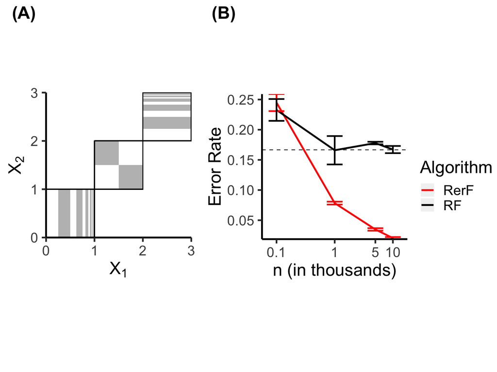

```r
err.plot <- ggplot(data = df, aes(x = n.samples, y = errors, color = Algorithm)) +
  geom_line(size=1) +
  geom_errorbar(aes(ymin=errors-se, ymax=errors+se), size = .9) +
  geom_hline(aes(yintercept = 1/6, linetype='g'), color = 'black', show.legend=FALSE, alpha = .8) +
  scale_linetype_manual(values = 2) +
  scale_x_continuous(trans='log10', breaks = c(100, 1000, 5000, 10000), labels = c(.1, 1, 5, 10)) +
  scale_y_continuous(expand = c(0,0)) +
  scale_color_manual(values=c("red", "black")) +
  labs(x = "n (in thousands)", y = "Error Rate")

err.plot <- err.plot +
  theme_gray(base_size = 20) +
  theme(panel.grid.major = element_blank(), panel.grid.minor = element_blank(),
    panel.background = element_blank(), axis.line = element_line(colour = "black", size = 1), aspect.ratio=1)

# Get legend
g_legend<-function(a.gplot){
  tmp <- ggplot_gtable(ggplot_build(a.gplot))
  leg <- which(sapply(tmp$grobs, function(x) x$name) == "guide-box")
  legend <- tmp$grobs[[leg]]
  return(legend)}

legend <- g_legend(err.plot)

out <- plot_grid(joint.distribution, err.plot + theme(legend.position = 'none'), legend, labels = c("(A)", "(B)"), ncol = 3, rel_widths = c(3.7, 4, 1.5), label_size = 20)

out
```

```r
ggsave('error_rate_consistency.pdf', plot = out, width = 7, height = 4)
```